# Matplotlib_Seaborn

## Contents

1. Introduction
2. Matplotlib
   - Lineplot
   - Multiple Subplots in One Figure
   - Histogram
3. Seaborn
   - Scatterplot with Multiple Semantic Variables
   - Visualize Statistical Estimation
   - Visualize Dataset Structure

### 1. Introduction

Numerical data may be encoded using dots, lines, or bars, to visually communicate a quantitative message. Effective visualization helps users analyze and reason about data and evidence. It makes complex data more accessible, understandable and usable. Users may have particular analytical tasks, such as showing comparisons or showing causality. The design principles of the graphics follow the tasks.  
Tables are generally used where users will look up a specific measurement, while charts of various types are used to show patterns or relationships in the data for one or more variables.

[figure not shown]

### 2. Matplotlib

Matplotlib is a Python 2D plotting library which produces publication quality figures in a variety of hardcopy formats and interactive environments across platforms. Matplotlib can be used in Python scripts, the Python and IPython shells, the Jupyter notebook, web application servers, and graphical user interface toolkits (e.g. Tkinter, Qt, wxPython). Matplotlib tries to make easy things easy and hard things possible. For simple and quick plotting the pyplot module provides a Matlab-like interface.

```python
import numpy as np
import pandas as pd
import matplotlib.pyplot as plt
plt.style.use('default')
```

### Lineplot

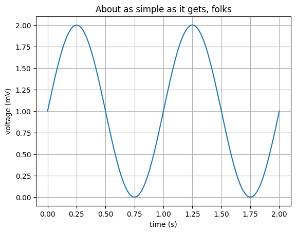

```python
# create a line plot with text labels
t = np.linspace(0, 2, 200)
s = 1 + np.sin(2*np.pi*t)

fig,ax = plt.subplots()
ax.plot(t,s)
ax.set(xlabel='time (s)',ylabel='voltage (mV)',title='About as simple as it gets, folks')
ax.grid()
plt.show()
```

### Multiple Subplots in One Figure

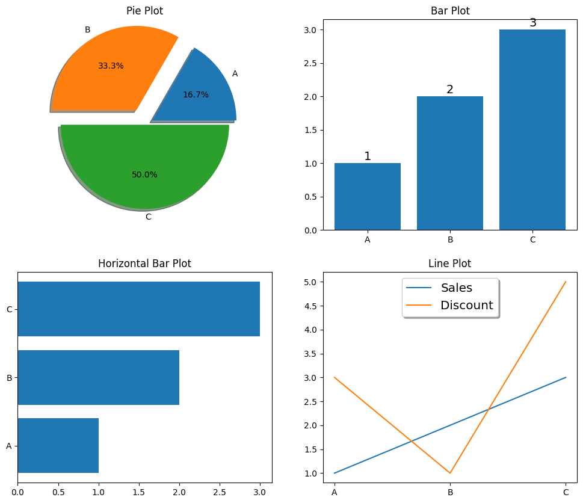

```python
fig, axs = plt.subplots(2,2,figsize=(12,10))

axs[0,0].pie([1,2,3],labels=['A','B','C'],explode=[0.1,0.2,0.0],autopct='%1.1f%%',shadow=True)
axs[0,0].set_title('Pie Plot')

rects = axs[0,1].bar(['A','B','C'],height=[1,2,3])
axs[0,1].set_title('Bar Plot')
for rect in rects:
    height = rect.get_height()
    axs[0,1].text(rect.get_x()+rect.get_width()/2.0,height+0.01,
    '%d'%int(height),fontdict={'fontsize':14},ha='center',va='bottom')

axs[1,0].barh(['A','B','C'],width=[1,2,3])
axs[1,0].set_title('Horizontal Bar Plot')

axs[1,1].plot(['A','B','C'],[1,2,3],label='Sales')
axs[1,1].plot(['A','B','C'],[3,1,5],label='Discount')
axs[1,1].set_title('Line Plot')
axs[1,1].legend(loc='upper center',shadow=True,fontsize='x-large')
plt.show()
```

### Histogram

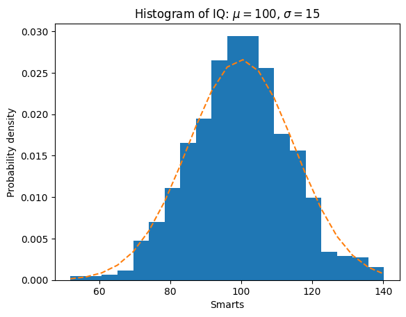

```python
# hist() function automatically generates histogram and returns bin counts or probabilities
np.random.seed(10)
mu = 100 # mean of distribution
sigma = 15 # standard deviation of distribution
x = mu + sigma*np.random.randn(1000)
num_bins = 20

fig,ax = plt.subplots()
# the histogram of the data
n,bins,patches = ax.hist(x,num_bins,density=1)
# add a fit line
y = (1/(np.sqrt(2*np.pi)*sigma))*np.exp(-(bins-mu)**2/(2*sigma**2))
ax.plot(bins,y,'--')
ax.set_xlabel('Smarts')
ax.set_ylabel('Probability density')
ax.set_title('Histogram of IQ: $\mu=100$, $\sigma=15$')
plt.show()
```

### 3. Seaborn

Seaborn is a library for making statistical graphics in Python. It is built on top of Matplotlib and closely integrated with Pandas and its data structures (e.g. DataFrame, Series). As another open-source software libarary for data analysis and visualization, Seaborn is a popular library for making appealing statistical data graphics in Python. It provides high level of graphic interface for drawing platform and helps to easily identify patterns and draw attention to key elements. It includes built-in themes for styling of informative data plots.

```python
import seaborn as sns
# apply the default settings
sns.set()
```

### Scatterplot with Multiple Semantic Variables

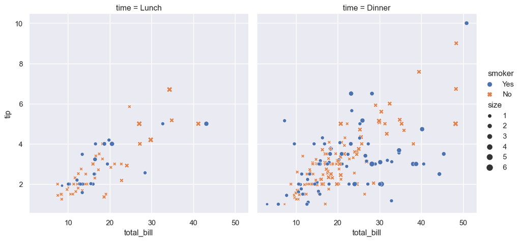

```python
tips = sns.load_dataset('tips')
# draw a faceted scatter plot with multiple semantic variables
sns.relplot(x='total_bill',y='tip',col='time',hue='smoker',style='smoker',size='size',data=tips);
```

### Visualize Statistical Estimation

Often we are interested in the average value of one variable as a function of other varaibles. Many seaborn functions can automatically perform the statistical estimation (for addressing these questions).

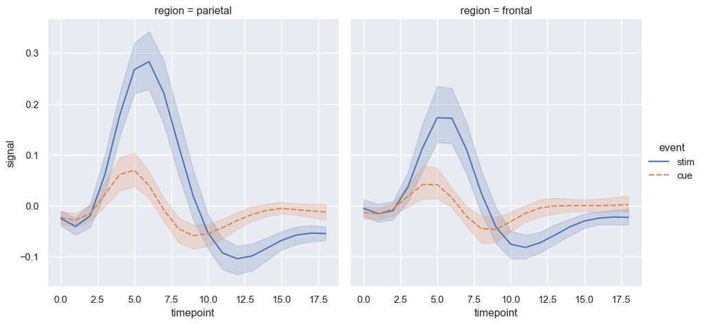

```python
fmri = sns.load_dataset('fmri')
sns.relplot(x='timepoint',y='signal',col='region',hue='event',style='event',kind='line',data=fmri);
```

Statistical estimation in Seaborn goes beyond descriptive statistics. For example, it is also possible to enhance a scatterplot to include a linear regression model (and its uncertainty).

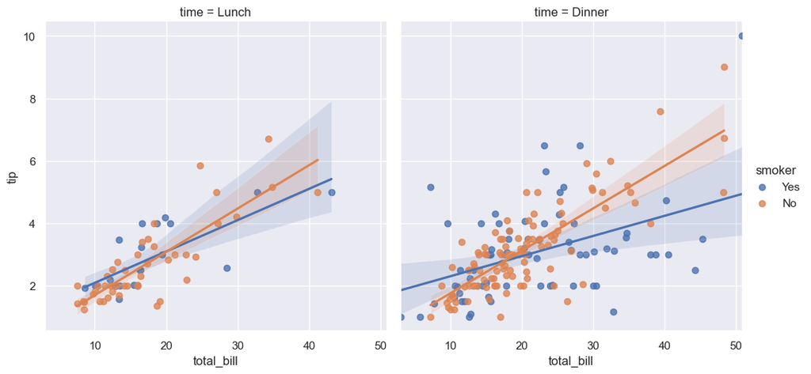

```python
sns.lmplot(x='total_bill',y='tip',col='time',hue='smoker',data=tips);
```

You could use kernel density estimation to represent the underlying distribution.

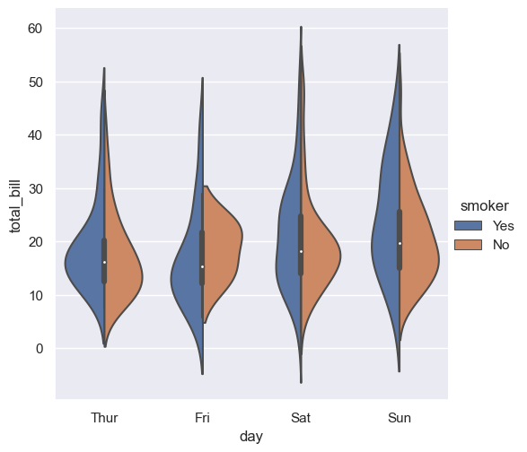

```python
sns.catplot(x='day',y='total_bill',hue='smoker',kind='violin',split=True,data=tips);
```

You could show the only mean value and its confidence interval within each nested category.

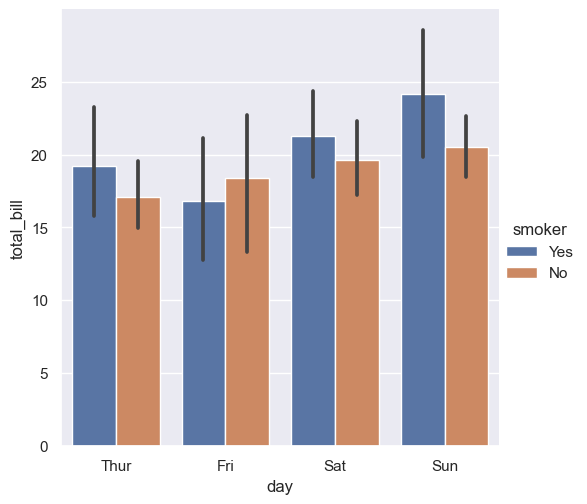

```python
sns.catplot(x='day',y='total_bill',hue='smoker',kind='bar',data=tips);
```

### Visualize Dataset Structure

jointplot() focuses on a single relationship.  
pairplot() takes a broader view, showing all pairwise relationships.  
They are oriented towards illuminating the structure of a dataset.

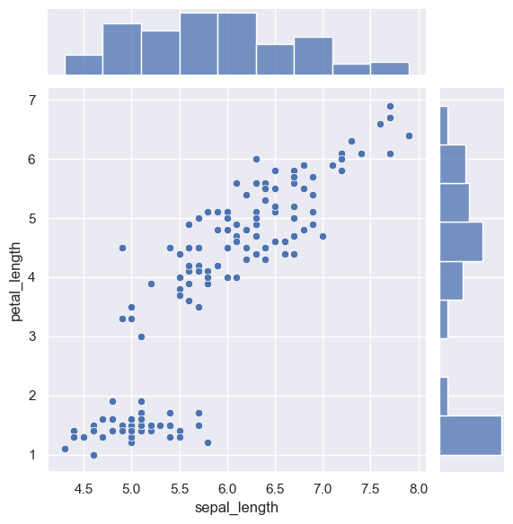

```python
iris = sns.load_dataset('iris')
sns.jointplot(x='sepal_length',y='petal_length',data=iris);
```

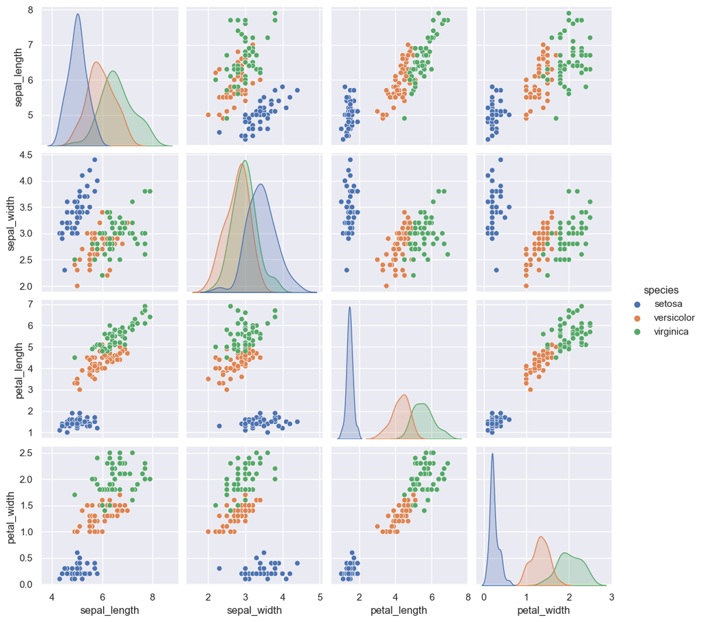

```python
sns.pairplot(data=iris,hue='species');
```